# Practical Machine Learning Course Project

Clay Burns

July 23, 2015

# Overview

This is a report for the Machine Learning Course offered by John Hopkins on Coursera. This report describes data processing and model building in steps performed on the Data Classification of Body Postures and Movements dataset. More information can be found here, http://groupware.les.inf.puc-rio.br/har

In brief terms the aim is to build a prediction model that can predict the technique of someone lifting weights based on data from a Fitbit. This model is both Train and tested.

# Data Acquisition

## Loading Data

The training and testing data can be read from these sources.

```r
url1 <- "http://d396qusza40orc.cloudfront.net/predmachlearn/pml-training.csv"
download.file(url1, destfile="pml-training.csv")
url2 <- "http://d396qusza40orc.cloudfront.net/predmachlearn/pml-testing.csv"
download.file(url2, destfile="pml-testing.csv")
dataTrain <- read.csv("pml-training.csv", header=TRUE)
dataTest <- read.csv("pml-testing.csv", header=TRUE)
```

The dataTest set will be used to examine accuracy while exploration and analysis are performed on the dataTrain set.

## Data Summmary

```r
summary(dataTrain$var_accel_forearm)
```

```
##    Min. 1st Qu.  Median    Mean 3rd Qu.    Max.    NA's
##   0.000   6.759  21.160  33.500  51.240 172.600   19216
```

```r
summary(dataTrain$var_accel_dumbbell)
```

```
##    Min. 1st Qu.  Median    Mean 3rd Qu.    Max.    NA's
##   0.000   0.378   1.000   4.388   3.434 230.400   19216
```

```r
summary(dataTrain$var_yaw_arm)
```

```
##      Min.   1st Qu.    Median      Mean   3rd Qu.      Max.      NA's
##     0.000     6.642   278.300  1056.000  1295.000 31340.000     19216
```

As can be seen above, many pieces of this data included NA variable in large amounts. For this reason, some data tidying will need to occur before proper model testing..

## Data Cleaning

```r
dataTidy <- dataTrain[,-c(grep("^amplitude|^kurtosis|^skewness|^avg|^cvtd_timestamp|^max|^min|^new_window|^raw_timestamp|^stddev|^var|^user_name|X",names(dataTrain)))]

paste("Complete Cases:")
```

```
## [1] "Complete Cases:"
```

```r
table(complete.cases(dataTidy))
```

```
##
##  TRUE
## 19622
```

After some data tidying, we now have only complete cases.

# Packages Preparation

For the model generation we will need the following packages.

```r
library(caret)
library(lattice)
library(gbm)
```

This will let us test Gradient Boosting versus Random Forest during the analysis. #Data splitting

Consider the size of the data set we have the ability to split into a secondary set for model validation. The size chosen here was 60% for training, and 40% for a preliminary test.

```r
set.seed(1337)
inTrain <- createDataPartition(y=dataTidy$classe,
                               p=0.6,list=FALSE)
dataTidyTrain <- dataTidy[inTrain,]
dataTidyTest <- dataTidy[-inTrain,]
```

# Model Selection

Since we would like to predict on classification random forests and Gradient Boosting will yield strong results. The rf & gbm algorithm should suit the data.

To handle selection the Kappa metric should provide a non-biased measure of prediction.

Lasting a 10-fold cross validation will reduce the possibility of over fitting.

```r
set.seed(1337)
# k-fold validation - 10-fold validation, use kappa as metric
fitControl <- trainControl(method = "cv",
                           number = 10)
gbmFit <- train(classe~., data=dataTidyTrain, method="gbm", metric="Kappa", trControl=fitControl,verbose=FALSE)
rfFit <- train(classe~.,data=dataTidyTrain,method="rf", metric="Kappa", trControl=fitControl)
```

# Model Comparison

Below, I create a box plot to examine the Kappa of each model. The Random Forest model produces stronger results, while the Gradient Boosting has a larger spread and seems to require more computational power.

```r
rValues <- resamples(list(rf=rfFit,gbm=gbmFit))
summary(rValues)
```

```
##
## Call:
## summary.resamples(object = rValues)
##
## Models: rf, gbm
## Number of resamples: 10
##
## Accuracy
##       Min. 1st Qu. Median   Mean 3rd Qu.   Max. NA's
## rf  0.9915  0.9941 0.9962 0.9958  0.9972 0.9992    0
## gbm 0.9796  0.9854 0.9877 0.9872  0.9896 0.9915    0
##
## Kappa
##       Min. 1st Qu. Median   Mean 3rd Qu.   Max. NA's
## rf  0.9893  0.9925 0.9952 0.9946  0.9965 0.9989    0
## gbm 0.9742  0.9815 0.9844 0.9838  0.9868 0.9892    0
```

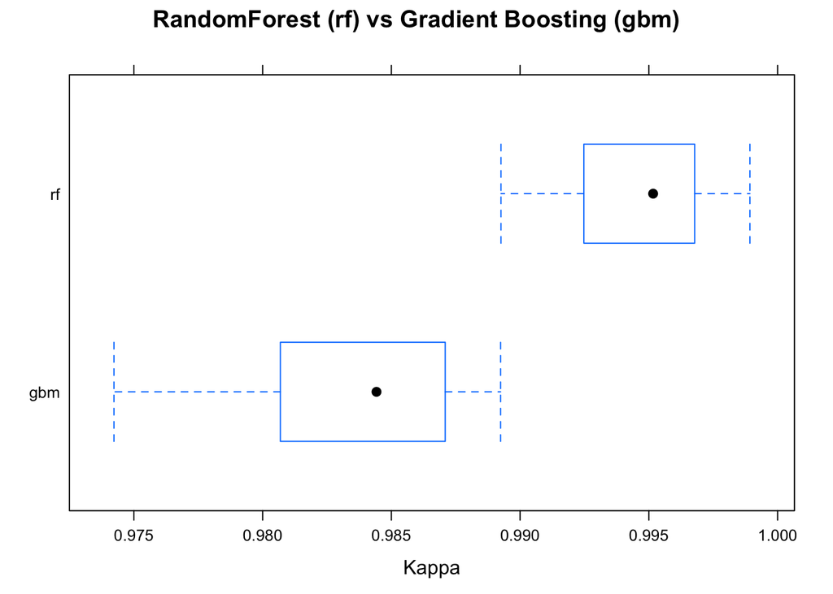

```r
bwplot(rValues,metric="Kappa",main="RandomForest (rf) vs Gradient Boosting (gbm)")
```

# Model Validation

Now with the Random Forest we can proceed to examine how well the Model fits on the dataTidyTest set. I have also included the detail of the selected model.

```r
rfFit
```

```
## Random Forest
##
## 11776 samples
##    53 predictor
##     5 classes: 'A', 'B', 'C', 'D', 'E'
##
## No pre-processing
## Resampling: Cross-Validated (10 fold)
##
## Summary of sample sizes: 10598, 10597, 10598, 10599, 10599, 10599, ...
##
## Resampling results across tuning parameters:
##
##   mtry  Accuracy   Kappa      Accuracy SD  Kappa SD
##    2    0.9932067  0.9914063  0.002499116  0.003162345
##   27    0.9957547  0.9946295  0.002333337  0.002952599
##   53    0.9933769  0.9916217  0.003146440  0.003981623
##
## Kappa was used to select the optimal model using  the largest value.
## The final value used for the model was mtry = 27.
```

The caret confusionMatrix function can help validate the selected model. It can be determined that models still performs within its initial kappa bounds with an extremely high accuracy.

```r
confusionMatrix(dataTidyTest$classe, predict(rfFit,dataTidyTest))
```

```
## Confusion Matrix and Statistics
##
##           Reference
## Prediction    A    B    C    D    E
##          A 2232    0    0    0    0
##          B    8 1507    3    0    0
##          C    0    5 1362    1    0
##          D    0    0   13 1273    0
##          E    0    0    2    3 1437
##
## Overall Statistics
##
##                Accuracy : 0.9955
##                  95% CI : (0.9938, 0.9969)
##     No Information Rate : 0.2855
##     P-Value [Acc > NIR] : < 2.2e-16
##
##                   Kappa : 0.9944
##  Mcnemar's Test P-Value : NA
##
## Statistics by Class:
##
##                      Class: A Class: B Class: C Class: D Class: E
## Sensitivity            0.9964   0.9967   0.9870   0.9969   1.0000
## Specificity            1.0000   0.9983   0.9991   0.9980   0.9992
## Pos Pred Value         1.0000   0.9928   0.9956   0.9899   0.9965
## Neg Pred Value         0.9986   0.9992   0.9972   0.9994   1.0000
## Prevalence             0.2855   0.1927   0.1759   0.1628   0.1832
## Detection Rate         0.2845   0.1921   0.1736   0.1622   0.1832
## Detection Prevalence   0.2845   0.1935   0.1744   0.1639   0.1838
## Balanced Accuracy      0.9982   0.9975   0.9930   0.9974   0.9996
```

# Final Model Testing

Final we will use the model to write the results on the test set, as instructed, for a final test.

```r
results <- predict(rfFit,newdata=dataTest)
print(as.data.frame(results))
```

```
##    results
## 1        B
## 2        A
## 3        B
## 4        A
## 5        A
## 6        E
## 7        D
## 8        B
## 9        A
## 10       A
## 11       B
## 12       C
## 13       B
## 14       A
## 15       E
## 16       E
## 17       A
## 18       B
## 19       B
## 20       B
```

```r
pml_write_files = function(x){
  n = length(x)
  for(i in 1:n){
    filename = paste0("problem_id_",i,".txt")
    write.table(x[i],file=filename,quote=FALSE,row.names=FALSE,col.names=FALSE)
  }
}
pml_write_files(results)
```